# NBA Win Predictions by C. Andrew Byrd IV

## FTR (Free Throws Made / Field Goal Att)

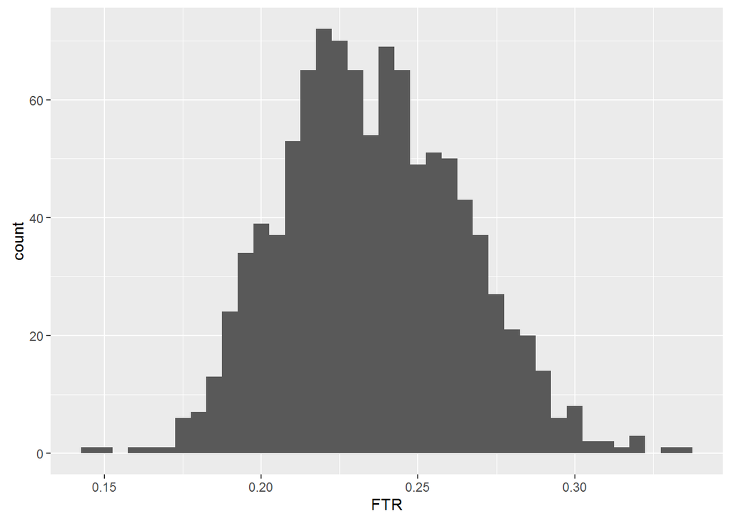

```
##    Min. 1st Qu.  Median    Mean 3rd Qu.    Max.
##  0.1456  0.2155  0.2341  0.2356  0.2554  0.3344
```

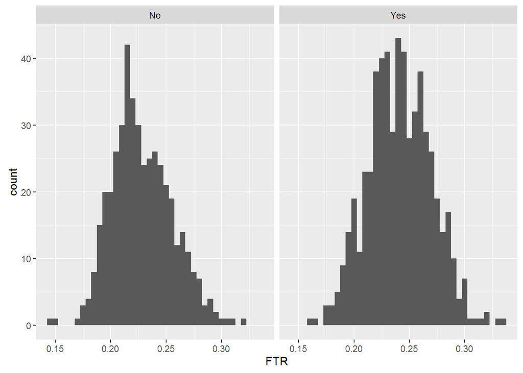

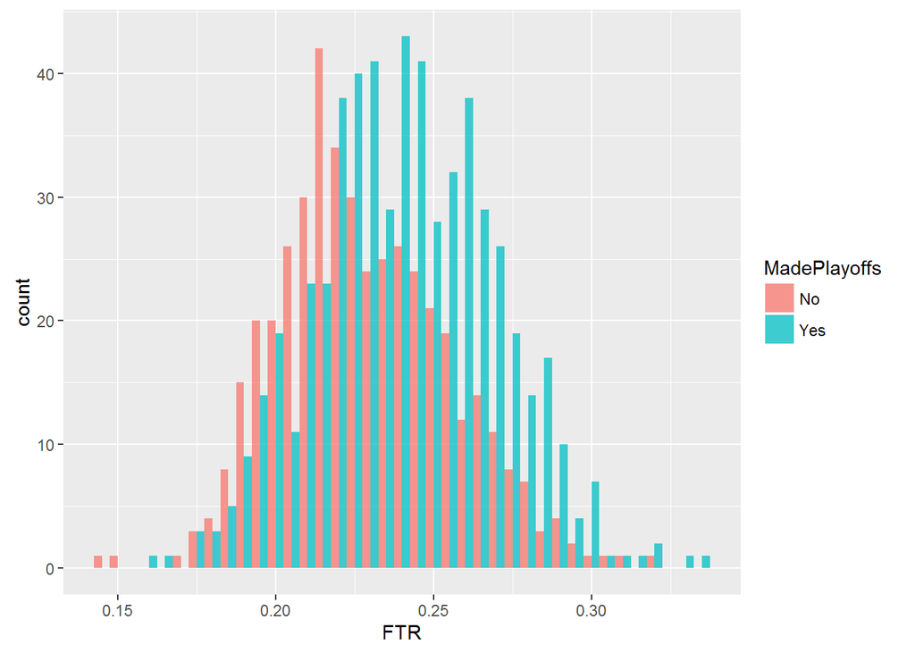

```
## nba$MadePlayoffs: No
##    Min. 1st Qu.  Median    Mean 3rd Qu.    Max.
##  0.1456  0.2094  0.2248  0.2283  0.2457  0.3209
## --------------------------------------------------------
## nba$MadePlayoffs: Yes
##    Min. 1st Qu.  Median    Mean 3rd Qu.    Max.
##  0.1612  0.2218  0.2404  0.2412  0.2615  0.3344
```

Teams should expect their “Free Throw Rate” to be between .15 and .33. The IQR is quite small at only about .04.

## OFTR (Opp. Free Throws Made / Opp. Field Goal Att)

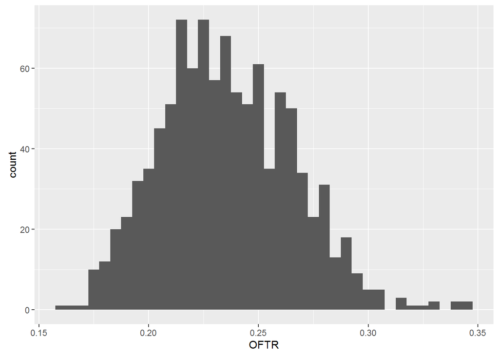

```
##    Min. 1st Qu.  Median    Mean 3rd Qu.    Max.
##  0.1580  0.2143  0.2338  0.2357  0.2574  0.3466
```

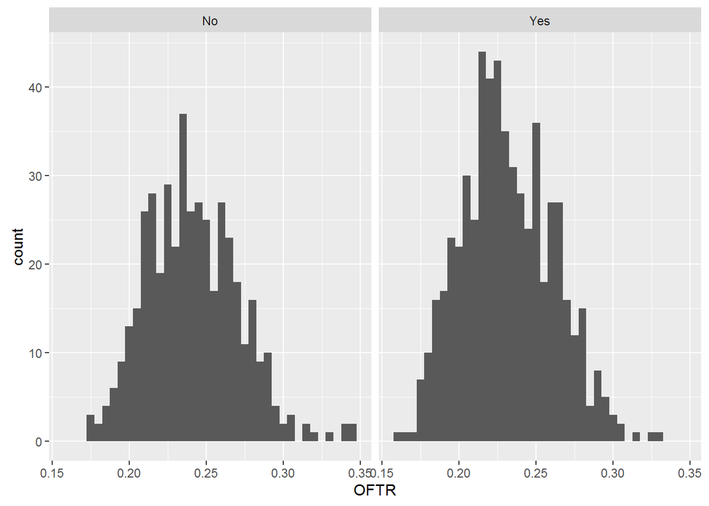

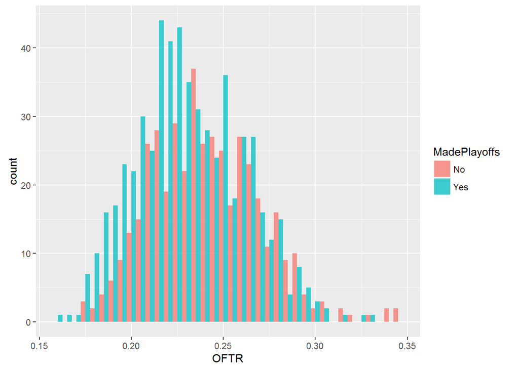

```
## nba$MadePlayoffs: No
##    Min. 1st Qu.  Median    Mean 3rd Qu.    Max.
##  0.1765  0.2184  0.2394  0.2413  0.2610  0.3466
## --------------------------------------------------------
## nba$MadePlayoffs: Yes
##    Min. 1st Qu.  Median    Mean 3rd Qu.    Max.
##  0.1580  0.2100  0.2283  0.2315  0.2518  0.3295
```

Very similar story with OFTR as compared to FTR.

## FTR_diff

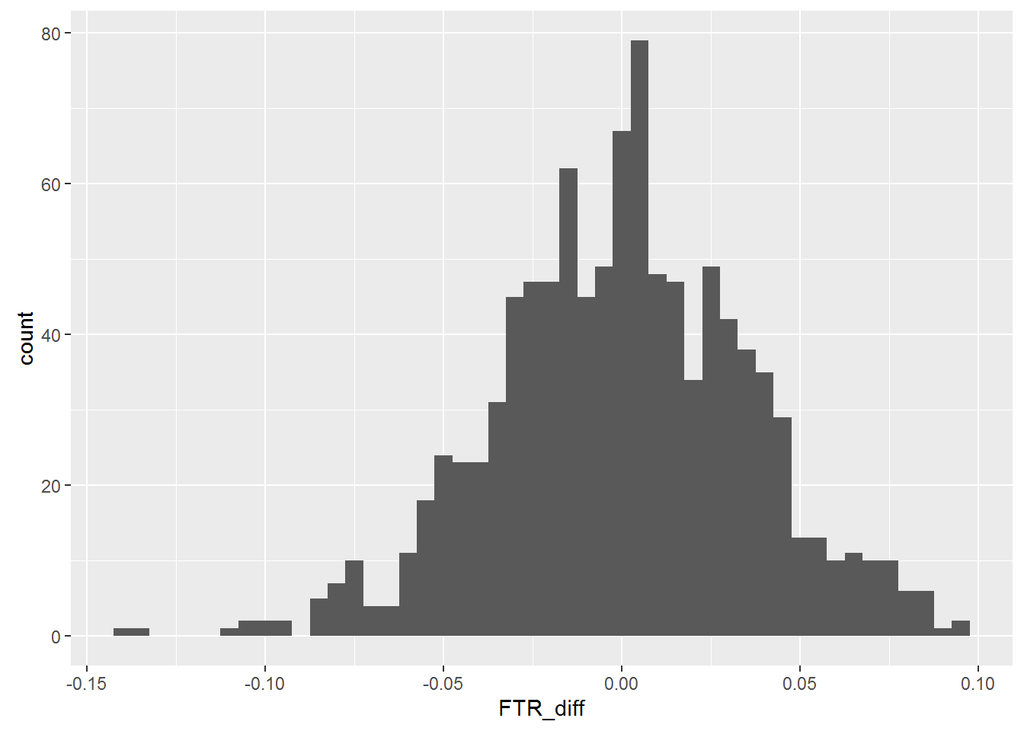

```
##       Min.    1st Qu.     Median       Mean    3rd Qu.       Max.
## -0.1376000 -0.0235700  0.0009545 -0.0001373  0.0244200  0.0967200
```

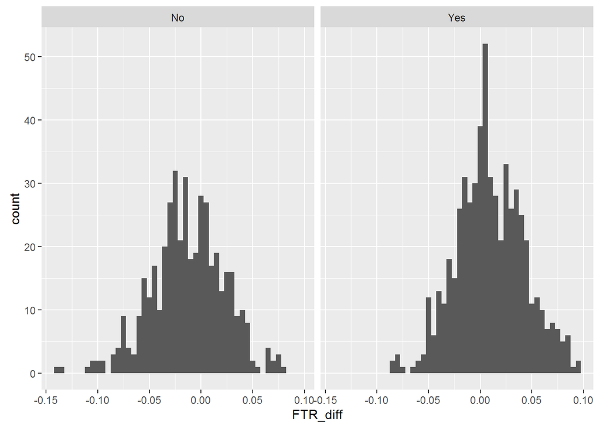

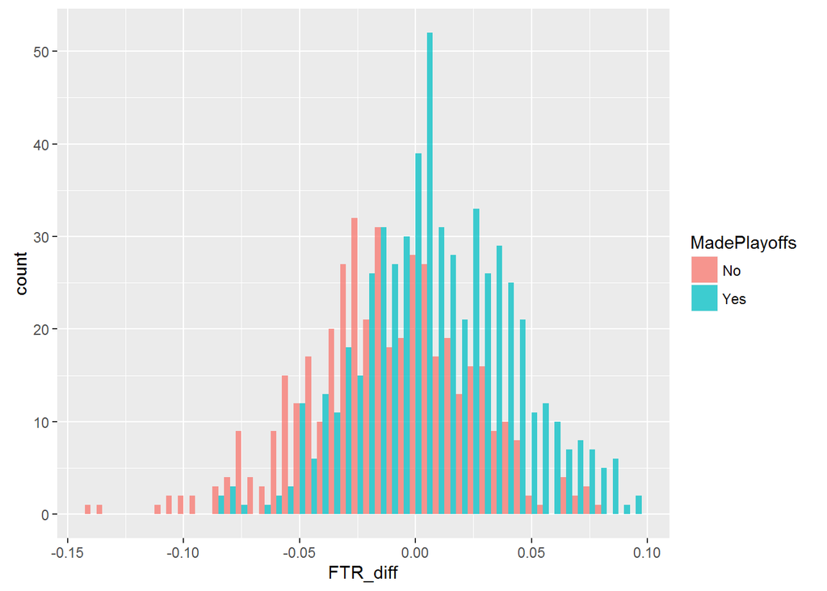

```
## nba$MadePlayoffs: No
##     Min.  1st Qu.   Median     Mean  3rd Qu.     Max.
## -0.13760 -0.03427 -0.01377 -0.01297  0.01040  0.08248
## --------------------------------------------------------
## nba$MadePlayoffs: Yes
##      Min.   1st Qu.    Median      Mean   3rd Qu.      Max.
## -0.085370 -0.012530  0.006060  0.009661  0.032490  0.096720
```

Another normal looking variable for the linear model.

Almost all, with the exception being the rebounding graphs, our data have a fairly normal look to it. The rebounding data is still somewhat normal but I think it almost has a bi-modal distribution. This is really great news as it allows us to continue with the process of building a model where these variables could predict the win % for a given team.

# Correlation Analysis

Since I hope to make a Win% Prediction model, I believe my bi-variate analysis and plots should focus on each variable’s relationship with the Win% variable to better understand their importance to the model. I also think I should ensure model viability by making sure the remaining variables are not too correlated with each other.

### Talk about some of the relationships you observed in this part of the investigation. How did the feature(s) of interest vary with other features in the dataset?

I found that the “difference” variables of EFG, TTP, and FTR definitely have a relationship with winning %. However, the RebRate difference variable did not have much of a relationship. This is quite surprising as I thought this would be one of the biggest factors of winning basketball games.

### Did you observe any interesting relationships between the other features (not the main feature(s) of interest)?

It’s very important to note that the four main difference pair do not have much correlation with each other. This is very important for the linear regression model assumptions.

### What was the strongest relationship you found?

As far as I can tell, the EFG difference variable vs winning % was the strongest relationship with a correlation of 85%. This makes a lot of sense. It’s extremely easy to say that teams that shoot well and keep opponents from shooting well, should win a lot of basketball games.

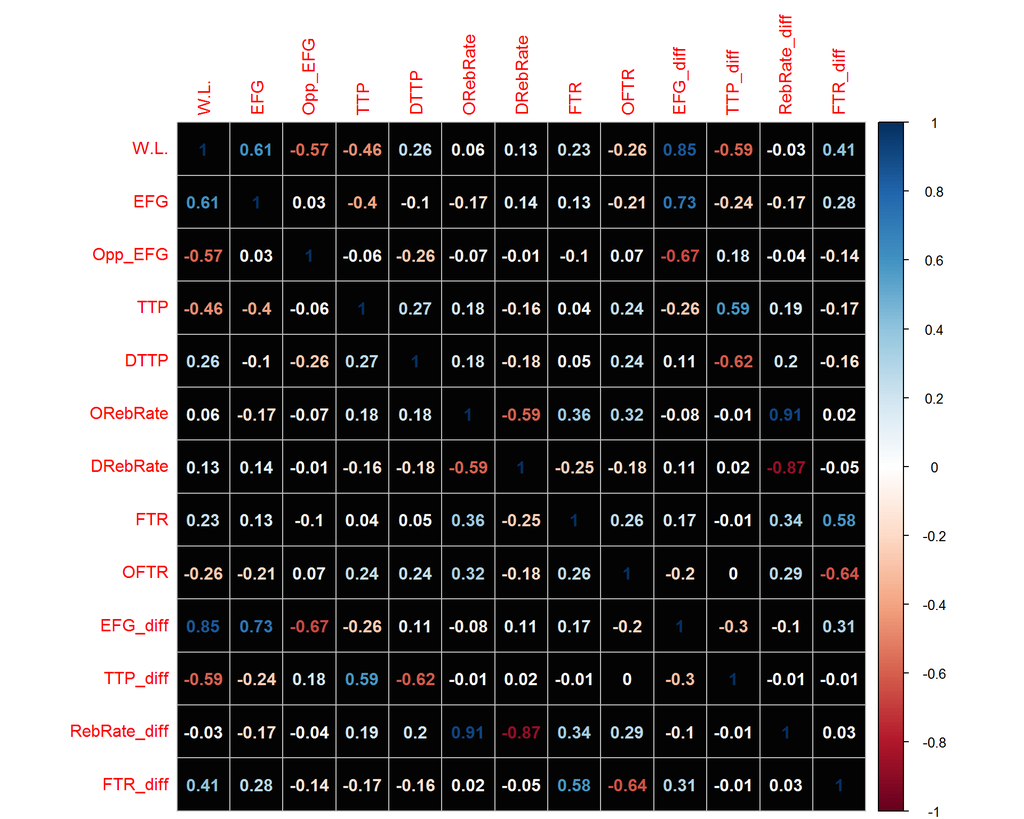

# Correlation Plots

The first 6 plots below show the strongest relationships with Win%. The narrative of it makes a lot of sense, if you shoot well, the other teams don’t shoot well, and you don’t turn the ball over, you are likely to win games.

## EFG vs W.L.

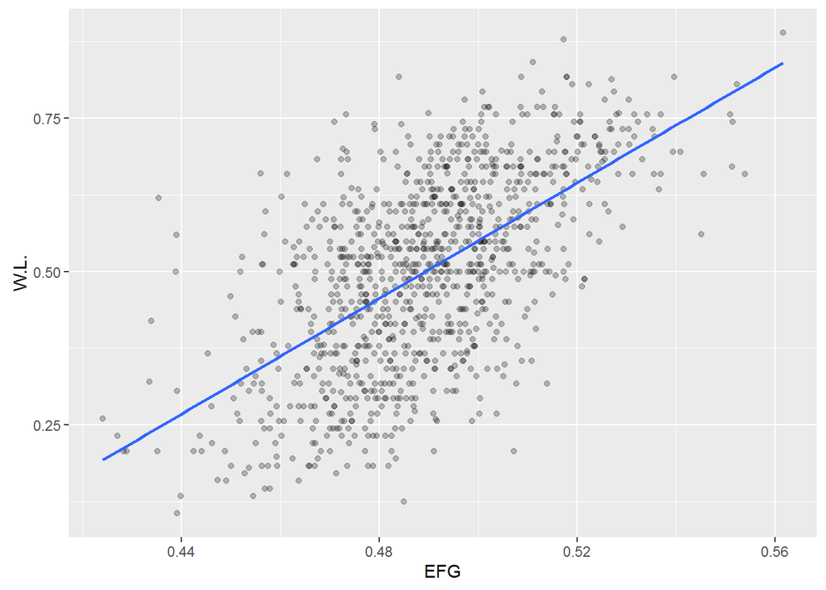

```
## Correlation: 0.6077237
```

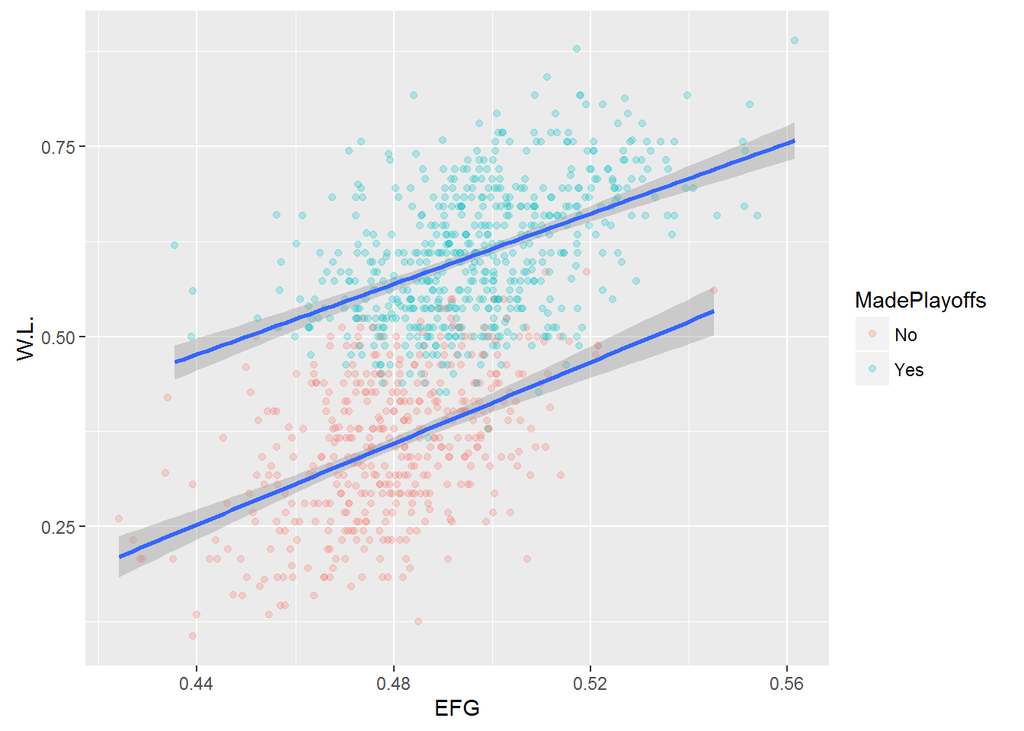

```
## nba$MadePlayoffs: No
##    Min. 1st Qu.  Median    Mean 3rd Qu.    Max.
##  0.4242  0.4693  0.4792  0.4792  0.4911  0.5451
## --------------------------------------------------------
## nba$MadePlayoffs: Yes
##    Min. 1st Qu.  Median    Mean 3rd Qu.    Max.
##  0.4355  0.4854  0.4965  0.4971  0.5086  0.5616
```

Fairly strong relationship. The better a team can shoot effectively, the more games they should win.

## Opp_EFG vs W.L.

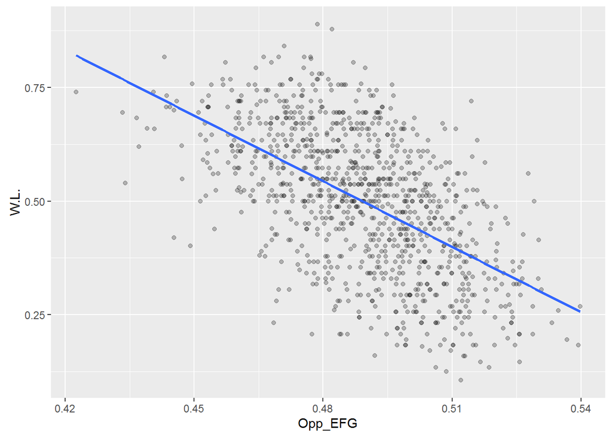

```
## Correlation: -0.5706009
```

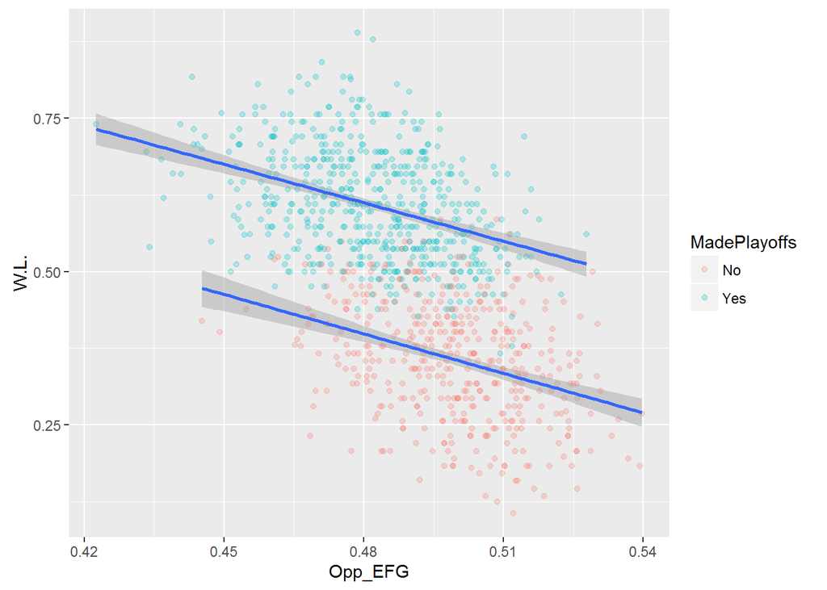

```
## nba$MadePlayoffs: No
##    Min. 1st Qu.  Median    Mean 3rd Qu.    Max.
##  0.4453  0.4888  0.4995  0.4991  0.5109  0.5398
## --------------------------------------------------------
## nba$MadePlayoffs: Yes
##    Min. 1st Qu.  Median    Mean 3rd Qu.    Max.
##  0.4226  0.4707  0.4824  0.4816  0.4930  0.5278
```

The variance looks a little larger but there is still a relationship.

## EFG_diff vs W.L.

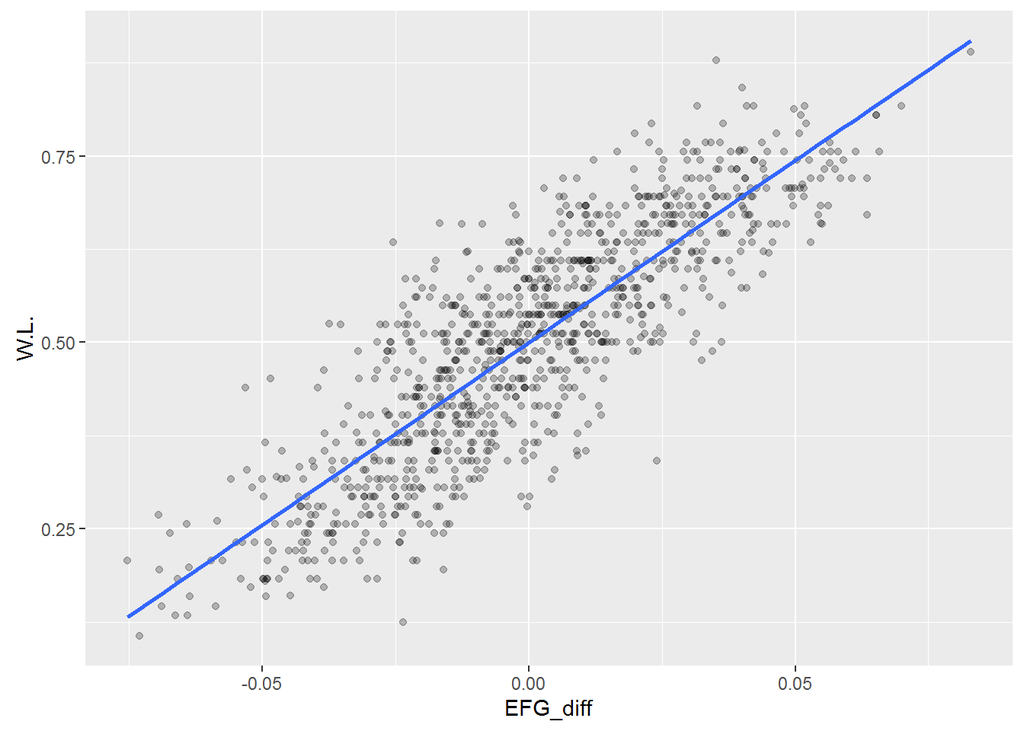

```
## Correlation: 0.8453532
```

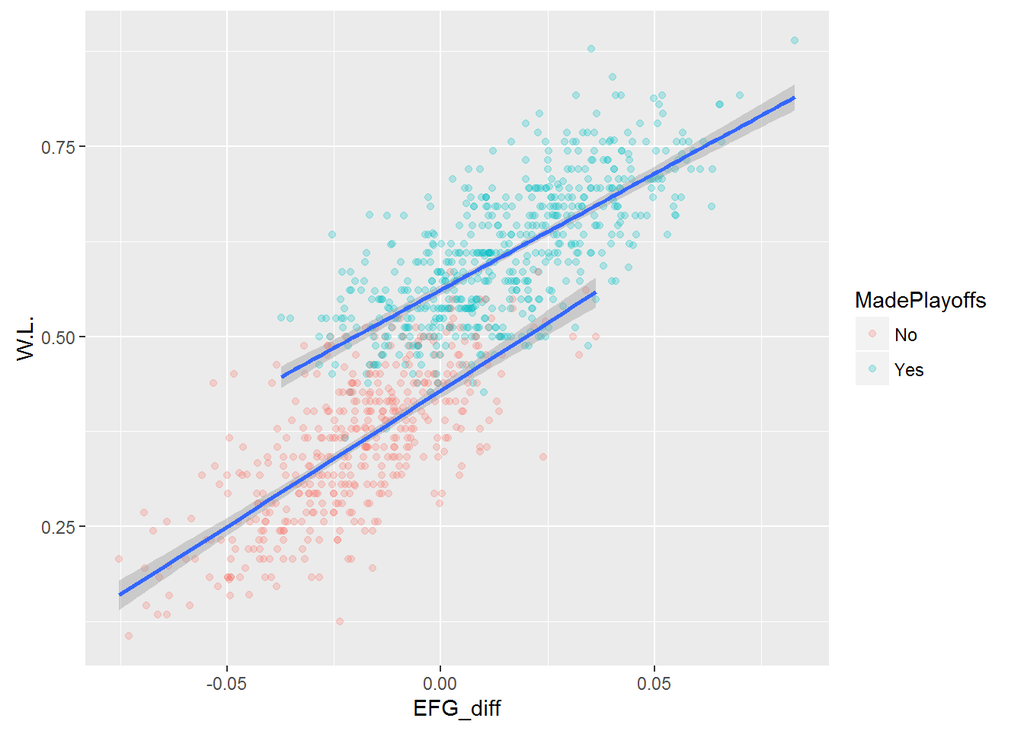

```
## nba$MadePlayoffs: No
##      Min.   1st Qu.    Median      Mean   3rd Qu.      Max.
## -0.075240 -0.031850 -0.019440 -0.019930 -0.007318  0.036250
## --------------------------------------------------------
## nba$MadePlayoffs: Yes
##       Min.    1st Qu.     Median       Mean    3rd Qu.       Max.
## -3.740e-02 -7.460e-06  1.382e-02  1.547e-02  3.061e-02  8.288e-02
```

This is my strongest relationship in the whole study. As mentioned early, for very obvious reasons. Adding the MadePlayoffs variable to the colors helps strengthen the visual of the relationship.

## TTP vs W.L.

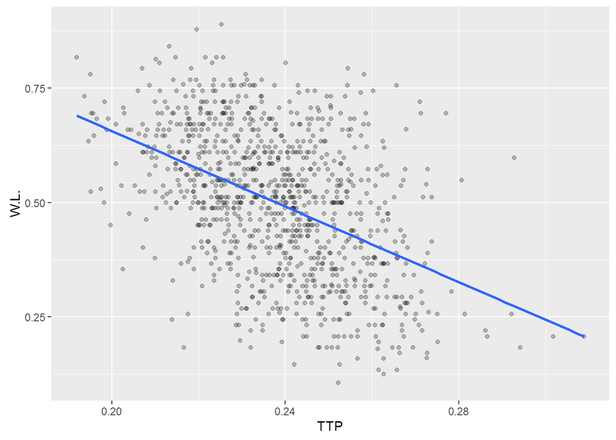

```
## Correlation: -0.4608119
```

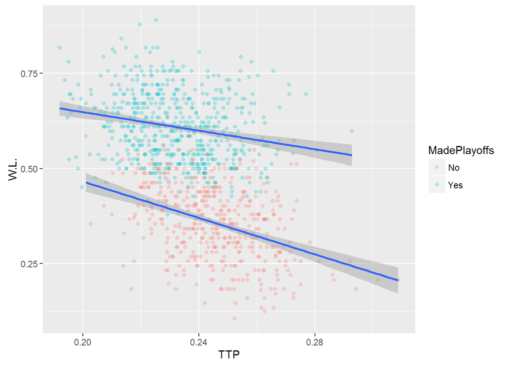

```
## nba$MadePlayoffs: No
##    Min. 1st Qu.  Median    Mean 3rd Qu.    Max.
##  0.2010  0.2336  0.2451  0.2453  0.2562  0.3089
## --------------------------------------------------------
## nba$MadePlayoffs: Yes
##    Min. 1st Qu.  Median    Mean 3rd Qu.    Max.
##  0.1919  0.2207  0.2319  0.2323  0.2432  0.2929
```

## TTP_diff vs W.L.

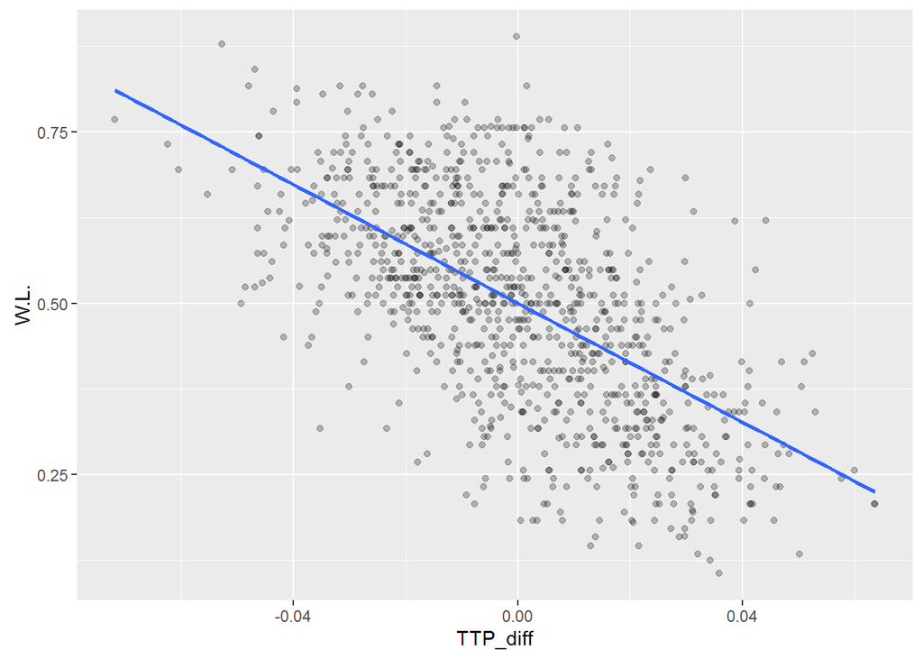

```
## Correlation: -0.5927464
```

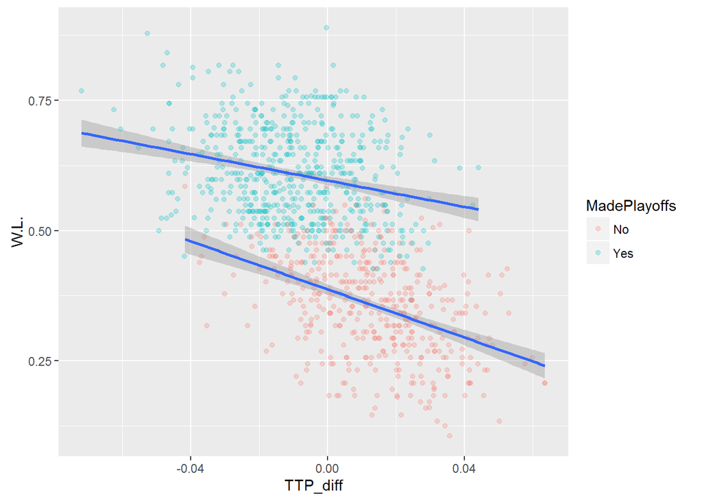

```
## nba$MadePlayoffs: No
##       Min.    1st Qu.     Median       Mean    3rd Qu.       Max.
## -0.0417100  0.0005568  0.0130100  0.0129800  0.0247700  0.0636400
## --------------------------------------------------------
## nba$MadePlayoffs: Yes
##      Min.   1st Qu.    Median      Mean   3rd Qu.      Max.
## -0.071890 -0.021550 -0.010360 -0.009807  0.002650  0.044160
```

Another fairly strong relationship that indicates that it is better to create turnovers than commit them.

## FTR_diff vs W.L.

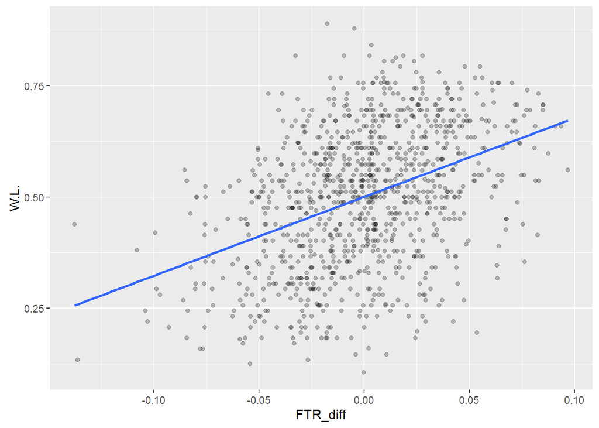

```
## Correlation: 0.4065486
```

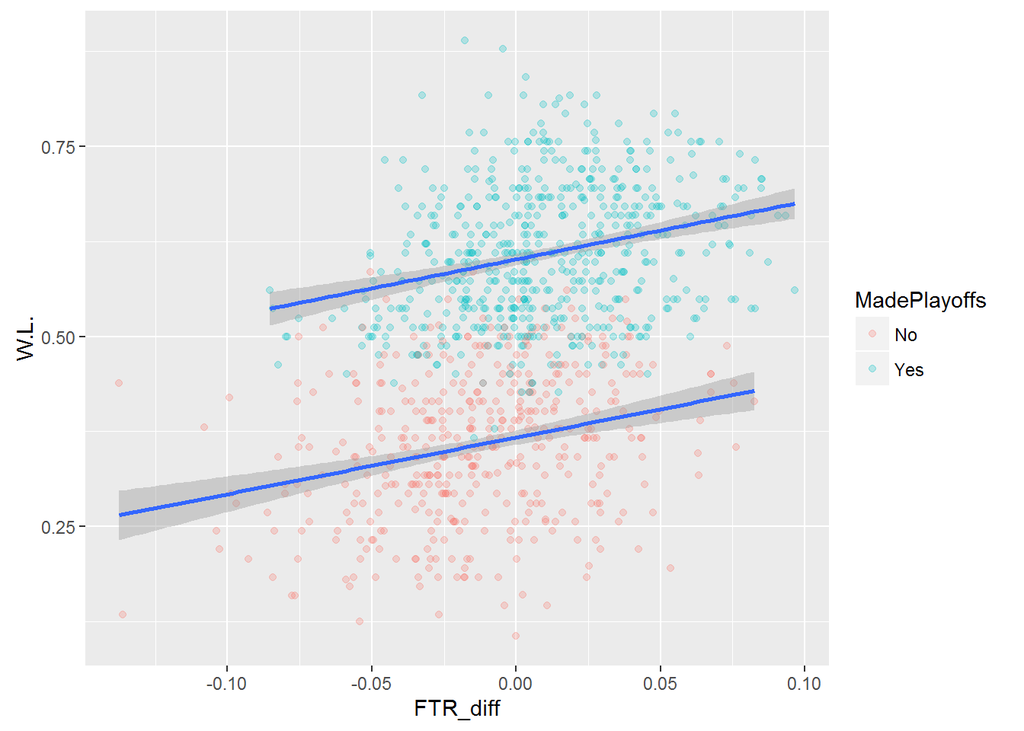

```
## nba$MadePlayoffs: No
##     Min.  1st Qu.   Median     Mean  3rd Qu.     Max.
## -0.13760 -0.03427 -0.01377 -0.01297  0.01040  0.08248
## --------------------------------------------------------
## nba$MadePlayoffs: Yes
##      Min.   1st Qu.    Median      Mean   3rd Qu.      Max.
## -0.085370 -0.012530  0.006060  0.009661  0.032490  0.096720
```

My correlation table shows that there is some correlation for these two variables but it is very difficult to see.

The next two plots of this section show the strongest relationships among non-Win% variables. They both make a lot of sense. In the first example, it’s easy to explain that teams that shoot well don’t have as many opportunities to turn the ball over. They are playing well and probably aren’t as likely to turn the ball over. In the second example, is a little more difficult to explain away but I could see a situation where teams that go for offensive rebounds are more likely to get fouled (i.e. big guys “hitting the boards” against the defense).

## EFG vs TTP

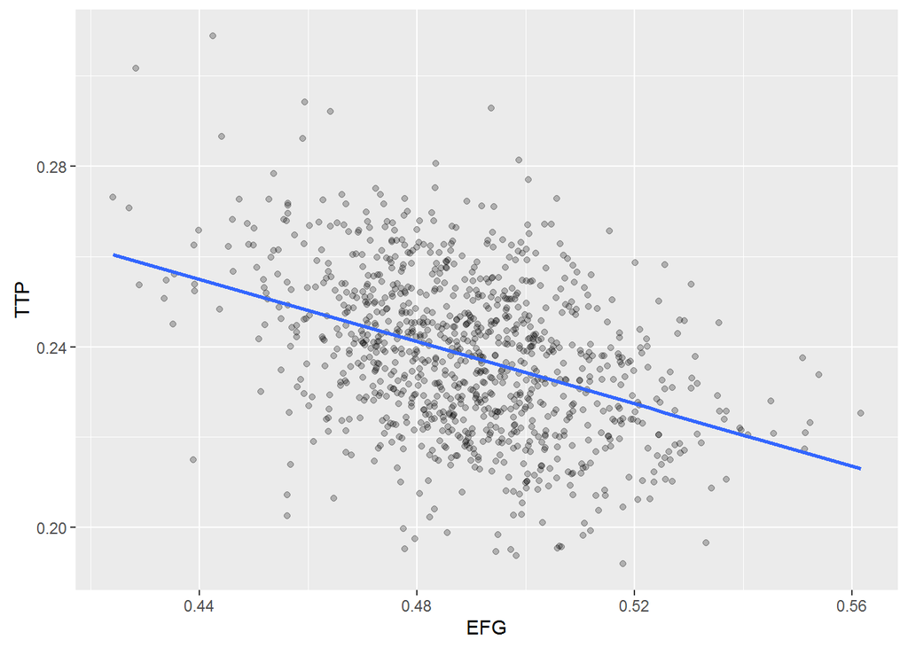

```
## Correlation: -0.3976078
```

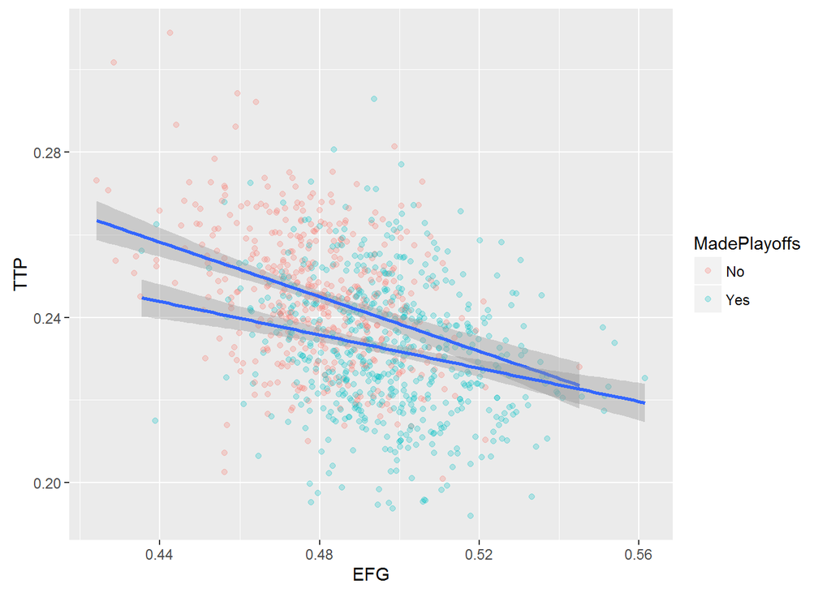

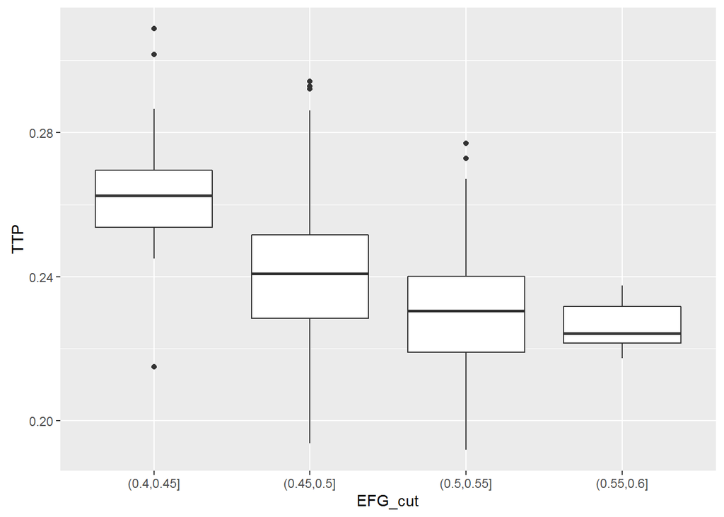

```
## nba$EFG_cut: (0.4,0.45]
##    Min. 1st Qu.  Median    Mean 3rd Qu.    Max.
##  0.2150  0.2537  0.2625  0.2631  0.2695  0.3089
## --------------------------------------------------------
## nba$EFG_cut: (0.45,0.5]
##    Min. 1st Qu.  Median    Mean 3rd Qu.    Max.
##  0.1937  0.2284  0.2409  0.2402  0.2516  0.2942
## --------------------------------------------------------
## nba$EFG_cut: (0.5,0.55]
##    Min. 1st Qu.  Median    Mean 3rd Qu.    Max.
##  0.1919  0.2190  0.2305  0.2304  0.2402  0.2771
## --------------------------------------------------------
## nba$EFG_cut: (0.55,0.6]
##    Min. 1st Qu.  Median    Mean 3rd Qu.    Max.
##  0.2174  0.2215  0.2242  0.2264  0.2317  0.2375
```

Adding the playoff coloring doesn’t clear the relationship. In general, it’s just not a strong relationship. I put the 3rd graph in to help clear up the relationship. I think there is some big variance for poor shooting teams but the average does tend to fall as the EFG goes up. This might say teams that are effective at shooting aren’t as likely to turn the ball over.

## FTR vs ORebRate

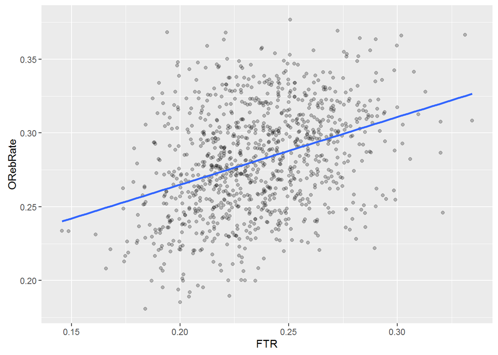

```
## Correlation: 0.3600009
```

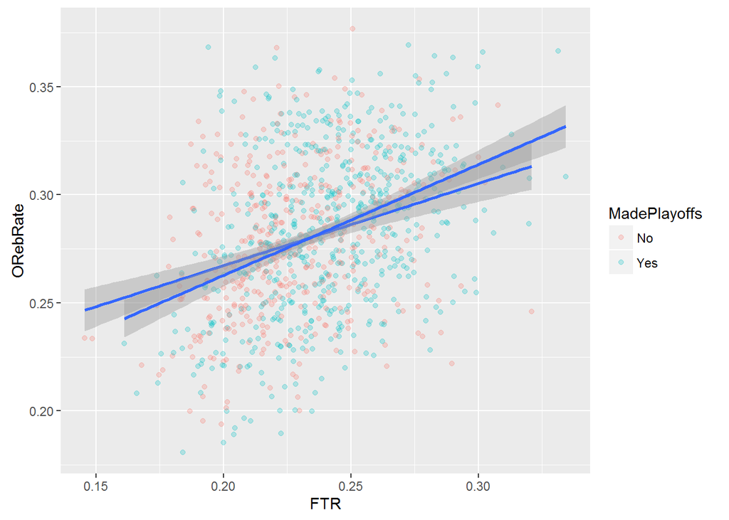

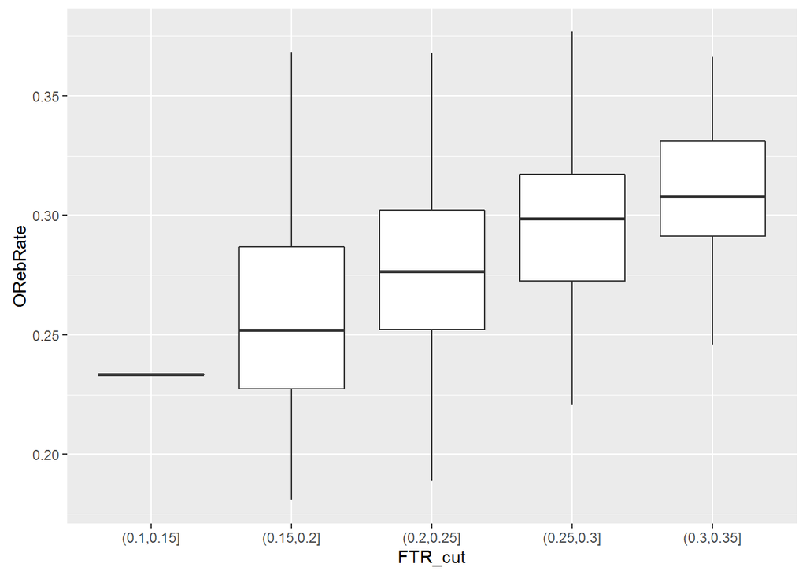

```
## nba$FTR_cut: (0.1,0.15]
##    Min. 1st Qu.  Median    Mean 3rd Qu.    Max.
##  0.2335  0.2335  0.2336  0.2336  0.2336  0.2336
## --------------------------------------------------------
## nba$FTR_cut: (0.15,0.2]
##    Min. 1st Qu.  Median    Mean 3rd Qu.    Max.
##  0.1808  0.2274  0.2520  0.2586  0.2869  0.3682
## --------------------------------------------------------
## nba$FTR_cut: (0.2,0.25]
##    Min. 1st Qu.  Median    Mean 3rd Qu.    Max.
##  0.1891  0.2522  0.2765  0.2778  0.3020  0.3679
## --------------------------------------------------------
## nba$FTR_cut: (0.25,0.3]
##    Min. 1st Qu.  Median    Mean 3rd Qu.    Max.
##  0.2207  0.2725  0.2985  0.2954  0.3171  0.3767
## --------------------------------------------------------
## nba$FTR_cut: (0.3,0.35]
##    Min. 1st Qu.  Median    Mean 3rd Qu.    Max.
##  0.2460  0.2913  0.3080  0.3120  0.3312  0.3666
```

The playoffs factor doesn’t seem to have much effect as there are green and red dots throughout the graph. Again, I created the 3rd graph to see if this would help paint the story of teams that are going for offensive rebounds are more likely to get fouled. I think there is a lot of variance but the averages do show the relationship we hope to see.

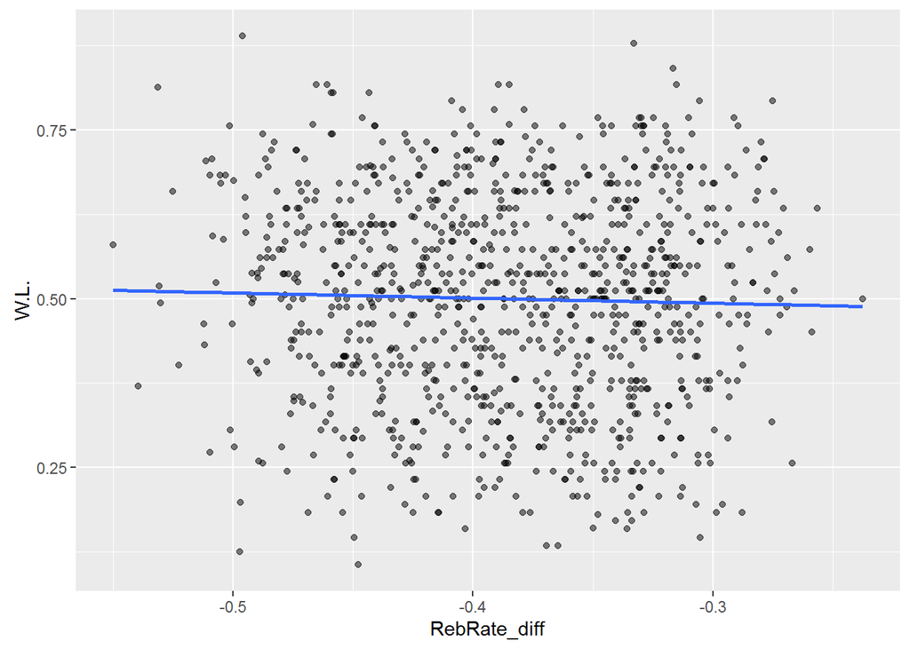

```
## Correlation: -0.02914051
```

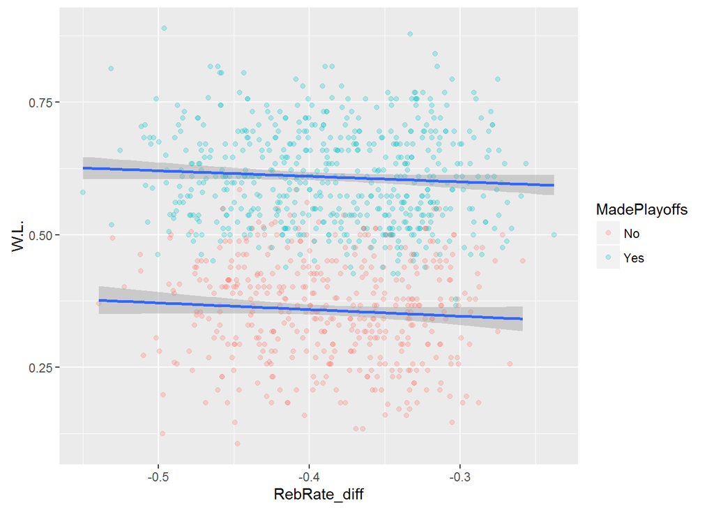

```
## nba$MadePlayoffs: No
##    Min. 1st Qu.  Median    Mean 3rd Qu.    Max.
## -0.5397 -0.4306 -0.3862 -0.3869 -0.3389 -0.2587
## --------------------------------------------------------
## nba$MadePlayoffs: Yes
##    Min. 1st Qu.  Median    Mean 3rd Qu.    Max.
## -0.5500 -0.4337 -0.3827 -0.3848 -0.3336 -0.2376
```

I’ve also included a few category variable plots.

## W.L. vs MadePlayoffs

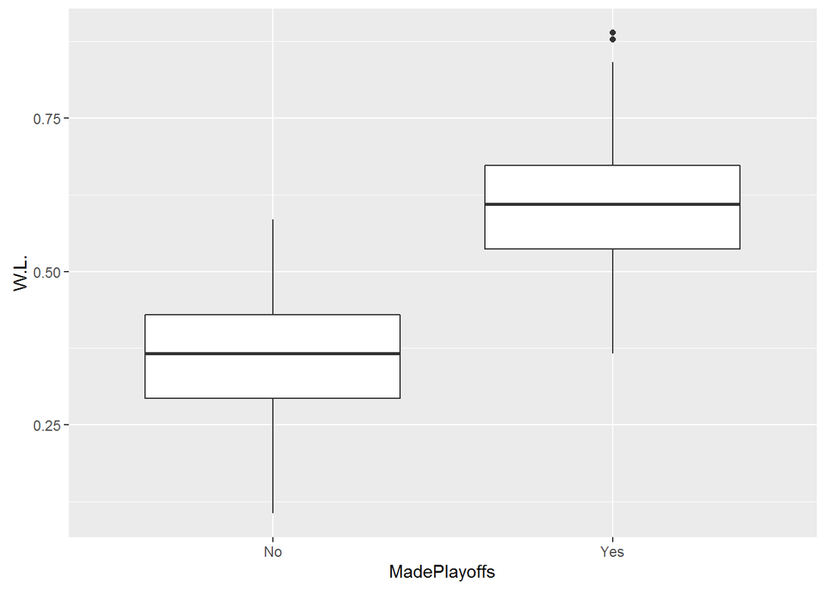

The two outliers at the top are not really outliers but the 1996 Bulls (who have the best single season NBA record at 72-10) and the 2016 Warriors (who are are close to breaking that record, currently sitting at 72-9).

## W.L. vs Conference

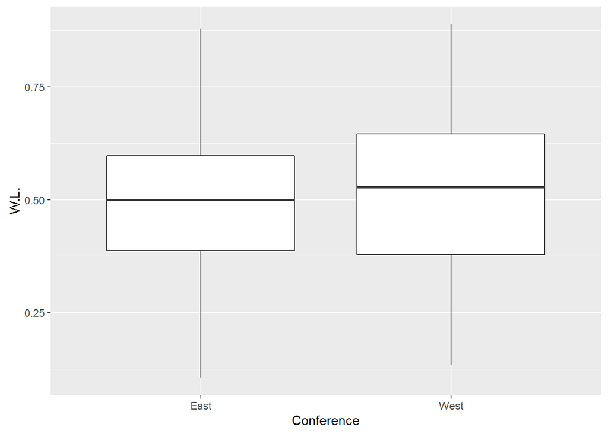

# Linear Regression Model

## Creating the Model

```
##
## Calls:
## m1: lm(formula = W.L. ~ EFG_diff, data = nba)
## m2: lm(formula = W.L. ~ EFG_diff + TTP_diff, data = nba)
## m3: lm(formula = W.L. ~ EFG_diff + TTP_diff + RebRate_diff, data = nba)
## m4: lm(formula = W.L. ~ EFG_diff + TTP_diff + RebRate_diff + FTR_diff,
##     data = nba)
##
## ==============================================================
##                      m1         m2         m3         m4
## --------------------------------------------------------------
##   (Intercept)      0.499***   0.500***   0.541***   0.527***
##                   (0.003)    (0.002)    (0.013)    (0.011)
##   EFG_diff         4.890***   4.242***   4.269***   3.879***
##                   (0.097)    (0.076)    (0.076)    (0.071)
##   TTP_diff                   -2.712***  -2.697***  -2.835***
##                              (0.096)    (0.096)    (0.085)
##   RebRate_diff                           0.106**    0.070*
##                                         (0.033)    (0.029)
##   FTR_diff                                          0.861***
##                                                    (0.051)
## --------------------------------------------------------------
##   R-squared           0.71       0.84       0.84       0.88
##   adj. R-squared      0.71       0.84       0.84       0.88
##   sigma               0.08       0.06       0.06       0.05
##   F                2534.17    2653.55    1789.00    1790.25
##   p                   0.00       0.00       0.00       0.00
##   Log-likelihood   1082.57    1375.89    1381.10    1507.22
##   Deviance            7.02       3.94       3.90       3.04
##   AIC             -2159.14   -2743.78   -2752.19   -3002.43
##   BIC             -2144.38   -2724.09   -2727.58   -2972.90
##   N                1014       1014       1014       1014
## ==============================================================
```

## Attach Predictions to DF

```
## [1] 0.04400423
```

Looks like the model predicts winning % with only a 4.4% absolute error rate! Not too bad.

## Did you create any models with your dataset? Discuss the strengths and limitations of your model.

Yes. The model is able to account for 88% of the variance in Winning percentage of teams each year. This is based on using the 4 pairing difference variables as inputs. This models allows one to fairly accurate predict the winning % based on those four variables. The most important factor, by far, is the EFG_diff variable as using that variable alone I am able to account for 71% of the variance.

# Final Plots and Summary

### Plot One - Histogram of Winning %, Broken out by Playoff & Non-Playoff Teams

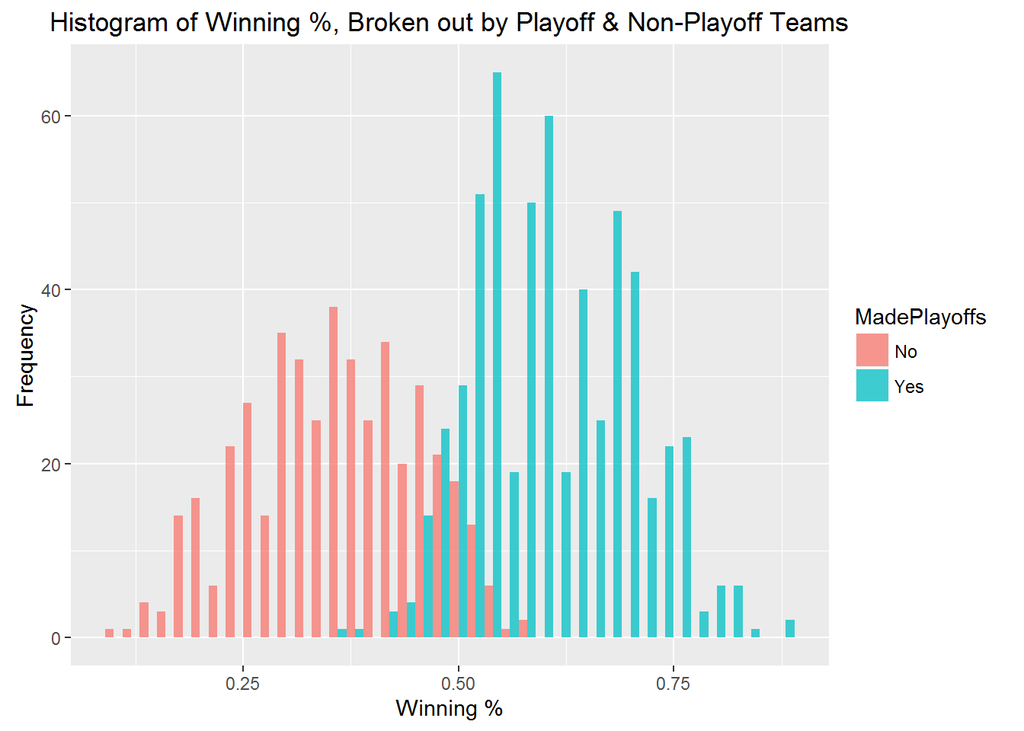

### Description One

I believe this charts states the most obvious statement. If your team wins basketball games, your team is more likely to make it to the playoffs. The colors really complete the picture as they are quite differentiated from the left and right. However, I will note there does appear to be instances of losing teams (teams with a Win% below 50%) making the playoffs and winning teams (teams with a Win% above 50%) not making the playoffs.

### Plot Two - EFG Difference vs Winning %

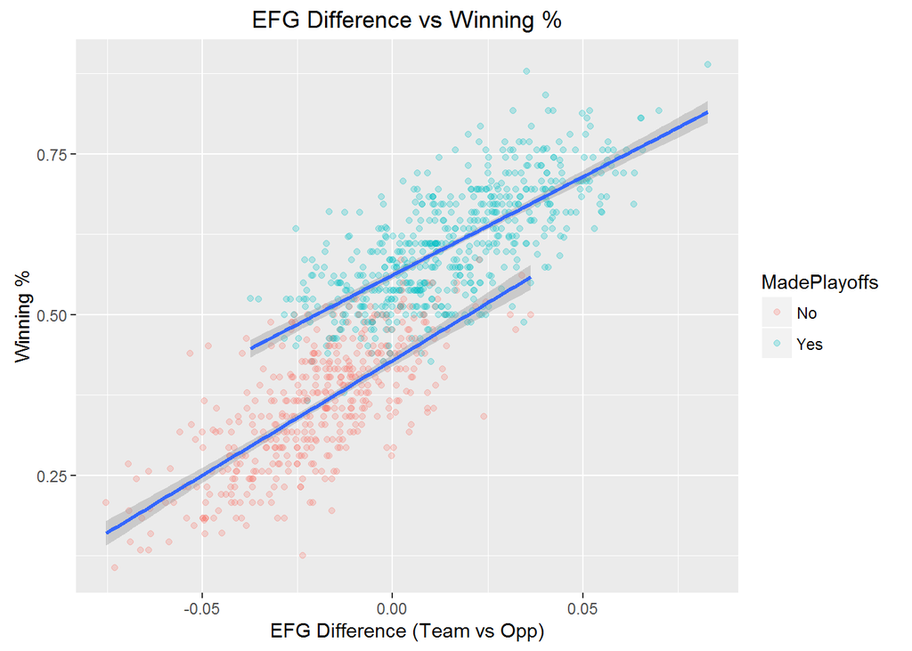

### Description Two

This chart helps display the strongest variable for the linear regression model. The EFG Difference variable controls about 71% of the variance of predicting winning %. I’ve also added some playoff coloring to help show the effectiveness of the variable.

### Plot Three

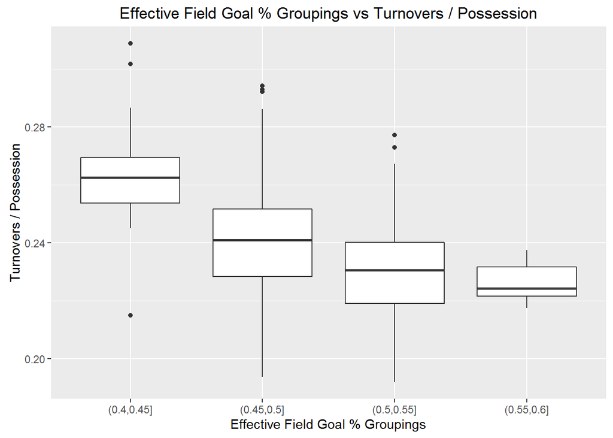

### Description Three

This graph is not critical to exploring the main goal of the project (Predicting Win%). However, I did want to give any noticeable relationship (In this case, about .4) an investigation. I was trying to better understand why this relationship is present. My first thought is that teams that shoot well are probably just playing good basketball and not turning the ball over as much. I believe there is a lot of variance but the mean/median does show the relationship we hope to see.. I think this happens some but it is nowhere near air tight.

# Reflection

This study was definitely a learning experience. It began by reading Winston’s chapters on quantifying wins within NBA, became slightly difficult scraping the data from Basketball Reference, and then became very tedious building graph after graph.

In Winston’s chapter on basketball, he only looked at one years worth of basketball statistics to calculate wins. I knew I could expand that study to as many years as they had relevant data but I would need to change from wins to winning % as some years don’t have the same amount of games played. Going from there I really had to dive in on the “rvest” package to learn more about web scraping in R (I’ve already completed the Data Wrangling Course and I think it helped a lot). I found that the data was mostly clean except for slight variations that occurs over the years at the Basketball Reference site (i.e. Some years they label 3P% as 3P, other it is labeled correctly.)

Once I had all my data, I originally only had the mindset of replicating the Winston linear model. I wanted to test the winning percentage model and call it a day. However, I decided to go along with the project outline and I found myself looking at the data in other ways that led to other questions I could be asking (i.e. Why do teams have less turnovers when they shoot well?). By the time I reached the conclusion, I didn’t even care about the original model because I wanted to investigate the other questions. I feel the project definitely opened my eyes about how much we can miss out on if we don’t give the exploratory data analysis the attention and detail it deserves.